# Term Deposit Sale Project by Samir Karandikar-R8

## 2. Build the ensemble models (Bagging and Boosting) and note the model performance by using different matrices. Use same metrics as in above model. (at least 3 algorithms) (15 marks)

### Ensemble Learning Bagging Method

```python
# Ensemble Learning Bagging using the model_entropy which was overfitted as starting point
# In Run 6 I tried using different n_estimators model
from sklearn.ensemble import BaggingClassifier

bgcl = BaggingClassifier(base_estimator=model_entropy, n_estimators=100,random_state=1)
#bgcl = BaggingClassifier(n_estimators=50,random_state=1)

bgcl = bgcl.fit(X_train, y_train)
```

```
0.9049690356826895
```

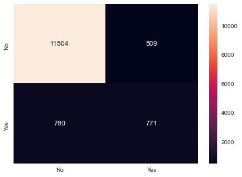

```python
y_predict = bgcl.predict(X_test)

print(bgcl.score(X_test , y_test))

cm=metrics.confusion_matrix(y_test, y_predict,labels=[0, 1])

df_cm = pd.DataFrame(cm, index = [i for i in ["No","Yes"]],
                  columns = [i for i in ["No","Yes"]])
plt.figure(figsize = (7,5))
sns.heatmap(df_cm, annot=True ,fmt='g')
```

```python
Results.loc[2,'Model']= 'Bagging'
Results.loc[2,'TP']=771
Results.loc[2,'TN']=11504
Results.loc[2,'FP']=509
Results.loc[2,'FN']=780
```

```python
Results.loc[2,'Train Accuracy']= round(bgcl.score(X_train, y_train),3)
Results.loc[2,'Testing Accuracy']= round(bgcl.score(X_test, y_test),3)
print('Training Accuracy =', Results.loc[2,'Train Accuracy'])
print('Testing Accuracy =', Results.loc[2,'Testing Accuracy'])
```

```
Training Accuracy = 1.0
Testing Accuracy = 0.905
```

```python
#Recall Score
from sklearn.metrics import recall_score
Results.loc[2,'Recall'] = round(recall_score(y_test, y_predict, average = 'macro'),3)
print("Bagging Recall Score =", Results.loc[2,'Recall'] )
```

```
Bagging Recall Score = 0.727
```

```python
#Precision Score
from sklearn.metrics import precision_score
Results.loc[2,'Precision'] = round(precision_score(y_test, y_predict, average = 'macro'),3)
print("Bagging Precision Score =", Results.loc[2,'Precision'] )
```

```
Bagging Precision Score = 0.769
```

```python
#F1 Score
from sklearn.metrics import f1_score
Results.loc[2,'F1'] = round(f1_score(y_test, y_predict, average = 'macro'),3)
print("Bagging F1 =", Results.loc[2,'F1'] )
```

```
Bagging F1 = 0.746
```

```python
from yellowbrick.classifier import ClassificationReport, ROCAUC
```

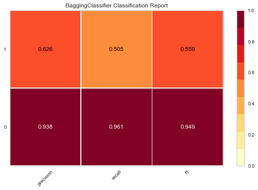

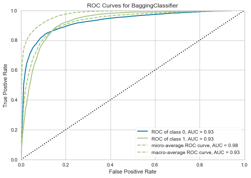

```python
# Visualize model performance with yellowbrick library
viz = ClassificationReport(BaggingClassifier(n_estimators=100, max_samples= .7, bootstrap=True, oob_score=True, random_state=1))
viz.fit(X_train, y_train)
viz.score(X_test, y_test)
viz.show()

roc = ROCAUC(BaggingClassifier(n_estimators=100, max_samples= .7, bootstrap=True, oob_score=True, random_state=1))
roc.fit(X_train, y_train)
roc.score(X_test, y_test)
roc.show()
```

### Catboosting Algorithm using Gradient Boosting

```python
from catboost import CatBoostClassifier, Pool, cv
from sklearn.metrics import accuracy_score
```

```python
#Using Catboosting Classifier
modelcb = CatBoostClassifier(
    custom_loss=['Accuracy'],
    random_seed=42,
    logging_level='Silent'
)
```

```python
categorical_features_indices = np.where(X.dtypes != np.float)[0]
```

```python
# Running model CatBoosting
modelcb.fit(
    X_train, y_train,
    cat_features=categorical_features_indices,
    eval_set=(X_test, y_test),
#     logging_level='Verbose',  # you can uncomment this for text output
    plot=True
);
```

```python
Results.loc[5,'Train Accuracy']= round(modelcb.score(X_train, y_train),3)
Results.loc[5,'Testing Accuracy']= round(modelcb.score(X_test, y_test),3)
print('Training Accuracy =', Results.loc[5,'Train Accuracy'])
print('Testing Accuracy =', Results.loc[5,'Testing Accuracy'])
```

```
Training Accuracy = 0.933
Testing Accuracy = 0.907
```

```
0.9074019463285167
```

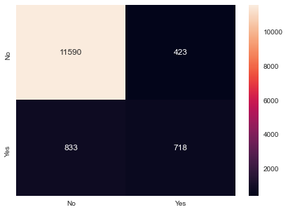

```python
y_predict = modelcb.predict(X_test)

print(modelcb.score(X_test , y_test))

cm=metrics.confusion_matrix(y_test, y_predict,labels=[0, 1])

df_cm = pd.DataFrame(cm, index = [i for i in ["No","Yes"]],
                  columns = [i for i in ["No","Yes"]])
plt.figure(figsize = (7,5))
sns.heatmap(df_cm, annot=True ,fmt='g')
```

```python
Results.loc[5,'Model']= 'Catboosting Gradient'
Results.loc[5,'TP']=718
Results.loc[5,'TN']=11590
Results.loc[5,'FP']=423
Results.loc[5,'FN']=833
```

```python
#Recall Score
from sklearn.metrics import recall_score
Results.loc[5,'Recall'] = round(recall_score(y_test, y_predict, average = 'macro'),3)
print("Catboosting Gradient Recall Score =", Results.loc[5,'Recall'] )
```

```
Catboosting Gradient Recall Score = 0.714
```

```python
#Precision Score
from sklearn.metrics import precision_score
Results.loc[5,'Precision'] = round(precision_score(y_test, y_predict, average = 'macro'),3)
print("Catboosting Gradient Precision Score =", Results.loc[5,'Precision'] )
```

```
Catboosting Gradient Precision Score = 0.781
```

```python
#F1 Score
from sklearn.metrics import f1_score
Results.loc[5,'F1'] = round(f1_score(y_test, y_predict, average = 'macro'),3)
print("Catboosting Gradient F1 =", Results.loc[5,'F1'] )
```

```
Catboosting Gradient F1 = 0.741
```

### Ensemble Learning - AdaBoosting

```python
# In Rev. 7 we try using more no of estimators than earlier
from sklearn.ensemble import AdaBoostClassifier
abcl = AdaBoostClassifier(n_estimators=100, random_state=1)
#abcl = AdaBoostClassifier( n_estimators=50,random_state=1)
abcl = abcl.fit(X_train, y_train)
```

```
0.9017988793866116
```

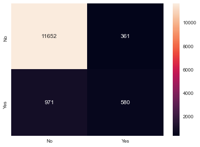

```python
y_predict = abcl.predict(X_test)
print(abcl.score(X_test , y_test))

cm=metrics.confusion_matrix(y_test, y_predict,labels=[0, 1])

df_cm = pd.DataFrame(cm, index = [i for i in ["No","Yes"]],
                  columns = [i for i in ["No","Yes"]])
plt.figure(figsize = (7,5))
sns.heatmap(df_cm, annot=True ,fmt='g')
```

```python
Results.loc[3,'Model']= 'AdaBoosting'
Results.loc[3,'TP']=580
Results.loc[3,'TN']=11652
Results.loc[3,'FP']=361
Results.loc[3,'FN']=971
```

```python
Results.loc[3,'Train Accuracy']= round(abcl.score(X_train, y_train), 3)
Results.loc[3,'Testing Accuracy']=round(abcl.score(X_test, y_test),3)
print('Training Accuracy =', Results.loc[3,'Train Accuracy'])
print('Testing Accuracy =', Results.loc[3,'Testing Accuracy'])
```

```
Training Accuracy = 0.902
Testing Accuracy = 0.902
```

```python
#Recall Score
from sklearn.metrics import recall_score
Results.loc[3,'Recall'] = round(recall_score(y_test, y_predict, average = 'macro'),3)
print("AdaBoosting Recall Score =", Results.loc[3,'Recall'] )
```

```
AdaBoosting Recall Score = 0.672
```

```python
#Precision Score
from sklearn.metrics import precision_score
Results.loc[3,'Precision'] = round(precision_score(y_test, y_predict, average = 'macro'),3)
print("AdaBoosting Precision Score =", Results.loc[3,'Precision'] )
```

```
AdaBoosting Precision Score = 0.77
```

```python
#F1 Score
from sklearn.metrics import f1_score
Results.loc[3,'F1'] = round(f1_score(y_test, y_predict, average = 'macro'),3)
print("Bagging F1 =", Results.loc[3,'F1'] )
```

```
Bagging F1 = 0.706
```

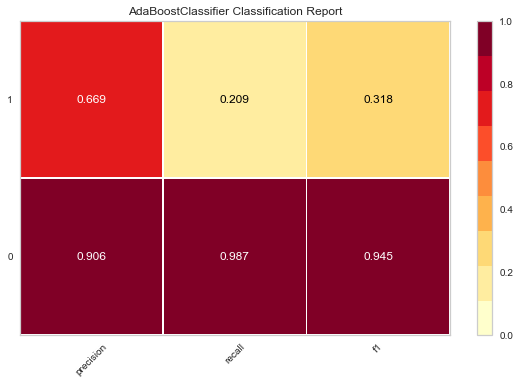

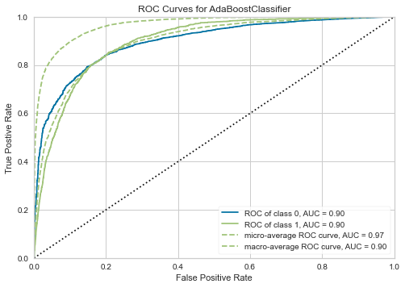

```python
# Visualize model performance with yellowbrick library
viz = ClassificationReport(AdaBoostClassifier(n_estimators= 100, learning_rate=0.1, random_state=1))
viz.fit(X_train, y_train)
viz.score(X_test, y_test)
viz.show()

roc = ROCAUC(AdaBoostClassifier(n_estimators= 100, learning_rate=0.1, random_state=1))
roc.fit(X_train, y_train)
roc.score(X_test, y_test)
roc.show()
```

```python
print(Results)
```

```
  Train Accuracy Testing Accuracy   TP     TN   FP    FN Recall Precision  \
0          0.903            0.901  524  11696  317  1027  0.656     0.771
1            0.9            0.901  526  11701  312  1025  0.657     0.774
2              1            0.905  771  11504  509   780  0.727     0.769
3          0.902            0.902  580  11652  361   971  0.672      0.77
4              1                2    3      4    5     6      7         8
5          0.933            0.907  718  11590  423   833  0.714     0.781

      F1                 Model
0  0.692   Logistic Regression
1  0.693         Decision Tree
2  0.746               Bagging
3  0.706           AdaBoosting
4      9                 blank
5  0.741  Catboosting Gradient
```

### Ensemble Random Forest Classifier

```python
# In Rev. 7 I increased the number of estimators to 100
from sklearn.ensemble import RandomForestClassifier
rfcl = RandomForestClassifier(n_estimators = 100, random_state=1,max_features=12)
rfcl = rfcl.fit(X_train, y_train)
```

```
0.9071070480684164
```

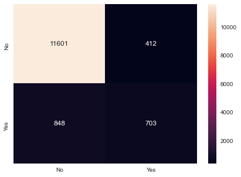

```python
y_predict = rfcl.predict(X_test)
print(rfcl.score(X_test, y_test))
cm=metrics.confusion_matrix(y_test, y_predict,labels=[0, 1])

df_cm = pd.DataFrame(cm, index = [i for i in ["No","Yes"]],
                  columns = [i for i in ["No","Yes"]])
plt.figure(figsize = (7,5))
sns.heatmap(df_cm, annot=True ,fmt='g')
```

```python
Results.loc[4,'Model']= 'Random Forest'
Results.loc[4,'TP']=703
Results.loc[4,'TN']=11601
Results.loc[4,'FP']=412
Results.loc[4,'FN']=848
```

```python
Results.loc[4,'Train Accuracy']= round(rfcl.score(X_train, y_train),3)
Results.loc[4,'Testing Accuracy']=round(rfcl.score(X_test, y_test),3)
print('Training Accuracy =', Results.loc[4,'Train Accuracy'])
print('Testing Accuracy =', Results.loc[4,'Testing Accuracy'])
```

```
Training Accuracy = 1.0
Testing Accuracy = 0.907
```

```python
#Recall Score
from sklearn.metrics import recall_score
Results.loc[4,'Recall'] = round(recall_score(y_test, y_predict, average = 'macro'),3)
print("Random Forest Recall Score =", Results.loc[4,'Recall'] )
```

```
Random Forest Recall Score = 0.709
```

```python
#Precision Score
from sklearn.metrics import precision_score
Results.loc[4,'Precision'] = round(precision_score(y_test, y_predict, average = 'macro'),3)
print("Random Forest Precision Score =", Results.loc[4,'Precision'] )
```

```
Random Forest Precision Score = 0.781
```

```python
#F1 Score
from sklearn.metrics import f1_score
Results.loc[4,'F1'] = round(f1_score(y_test, y_predict, average = 'macro'),3)
print("Random Forest F1 =", Results.loc[4,'F1'] )
```

```
Random Forest F1 = 0.738
```

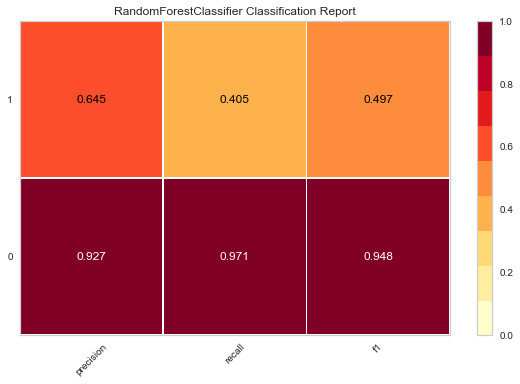

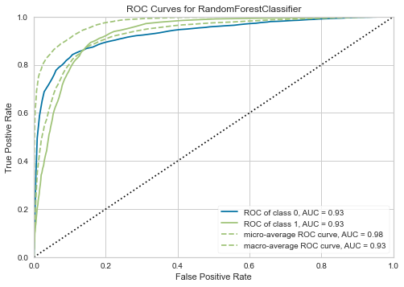

```python
# Visualize model performance with yellowbrick library
viz = ClassificationReport(RandomForestClassifier(n_estimators = 100))
viz.fit(X_train, y_train)
viz.score(X_test, y_test)
viz.show()

roc = ROCAUC(RandomForestClassifier(n_estimators = 100))
roc.fit(X_train, y_train)
roc.score(X_test, y_test)
roc.show()
```

## 3. Make a DataFrame to compare models and their metrics. Give conclusion regarding the best algorithm and your reason behind it. (5 marks)

```python
print(Results)
#Dataframe Results has been populated as each algorithm was executed.
#Please see the combined results of the models run.
# The results dataframe was saved as an excel spreadsheet Output.xslx
# And then various revisions of the program were run to add or delete attributes,
# remove the outliers, change the hyperparameters, and the results obtained are discussed in this section.
```

```
  Train Accuracy Testing Accuracy   TP     TN   FP    FN Recall Precision  \
0          0.903            0.901  524  11696  317  1027  0.656     0.771
1            0.9            0.901  526  11701  312  1025  0.657     0.774
2              1            0.905  771  11504  509   780  0.727     0.769
3          0.902            0.902  580  11652  361   971  0.672      0.77
4              1            0.907  703  11601  412   848  0.709     0.781
5          0.933            0.907  718  11590  423   833  0.714     0.781

      F1                 Model
0  0.692   Logistic Regression
1  0.693         Decision Tree
2  0.746               Bagging
3  0.706           AdaBoosting
4  0.738         Random Forest
5  0.741  Catboosting Gradient
```

```python
writer = pd.ExcelWriter('output.xlsx')
# write dataframe to excel to study the data independently
Results.to_excel(writer)
# save to excel
writer.save()
#Please see below consolidation of various revisions of the program run in order to get comparative results.
```

## Conclusion

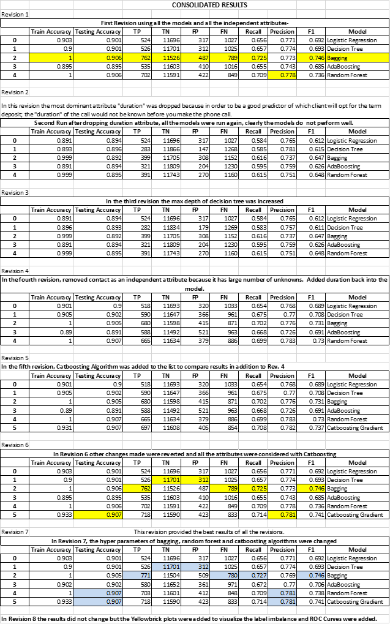

### Performance metrics

**Testing Accuracy** The best Testing Accuracy of 0.907 was achieved by Random Forest and Catboosting algorithms. It is the fraction of all observations that were correctly classified by the model. Although there are other performance metrics of the models that are more important based on the business goal behind conducting the analysis.

- **precision** Precision is a measure of a classifier’s exactness. For each class, it is defined as the ratio of true positives to the sum of true and false positives. Said another way, “for all instances classified positive, what percent was correct?”. In this case the Random Forest and Catboosting algorithm provided the highest precision.
- **recall** Recall is a measure of the classifier’s completeness; the ability of a classifier to correctly find all positive instances. For each class, it is defined as the ratio of true positives to the sum of true positives and false negatives. Said another way, “for all instances that were actually positive, what percent was classified correctly?” In this case Bagging algorithm achieved the best Recall score.
- **f1 score** The F1 score is a weighted harmonic mean of precision and recall such that the best score is 1.0 and the worst is 0.0. Generally speaking, F1 scores are lower than accuracy measures as they embed precision and recall into their computation. As a rule of thumb, the weighted average of F1 should be used to compare classifier models, not global accuracy.

### Using F1 as the measure for comparing the models, the best F1 score of 0.746 was provided by Bagging algorithm, therefore it would be considered the best algorithm for this data set.

**Observations of Label imbalance** Significant imbalance was observed between Class 1 and 0. All models provided much better metrics for Class 0. Bagging algorithm provided higher f1 score of 0.559 and 0.949 for Classes 1 and 0 respectively. These were the highest f1 scores observed when compared to Ada Boost and Random Forest models. ROC and ROC/AUC data was observed and it was comparable or better for Bagging algorithm than other algorithms.